# neuralnet_rmd

Сравниваем подгонку ряда (красный цвет) и исходный ряд (черный цвет)

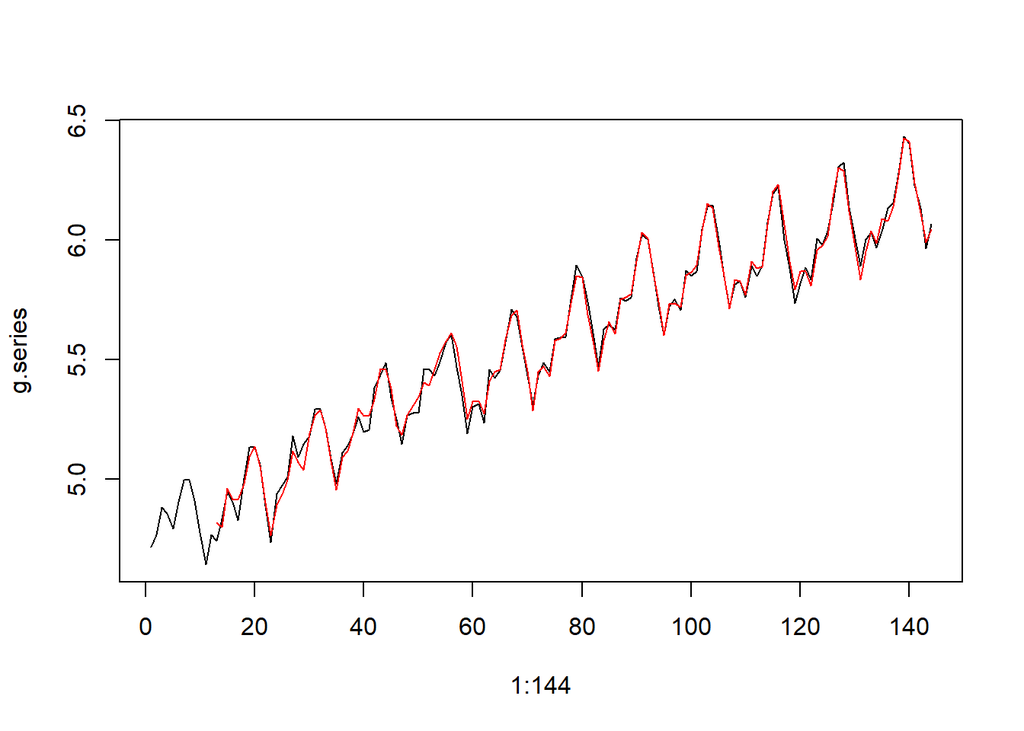

```r
plot(1:144, g.series, type = "l")
lines(13:144, g.net$fitted.values, col = "red")
```

Начинаем вычислять прогнозируемые значения Первый вектор входов == последние 12 наблюдений ряда

```r
g.forecast <- g.2[nrow(g.2), -1]

#  Горизонт прогноза - 12, по условию
pred.n <- 12

#  Вектор спрогнозированных значений
pred.1 <- rep(-9999, pred.n)

for (i in 1:pred.n)
{
  pred.1[i] <- predict(g.net, g.forecast, type = "raw")
  g.forecast <- c( g.forecast[-1], pred.1[i])
}
```

Строим график с результатами, черным цветом исходный ряд, красным цветом подгонка, синим цветом прогноз Берем *экспоненту*, так как прогноз был для ряда из логарифмов

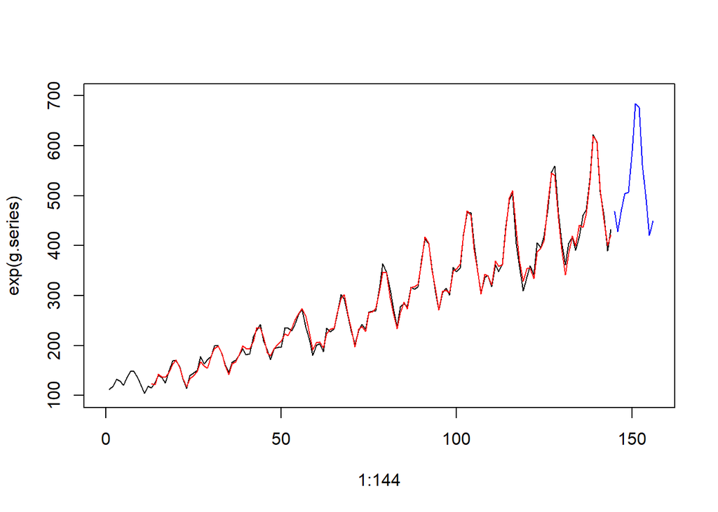

```r
plot(1:144, exp(g.series), type = "l", xlim = c(0, 144+pred.n), ylim = c(100, 700))
lines(13:144, exp(g.net$fitted.values), col = "red")
lines((144+1):(144+pred.n), exp(pred.1), col = "blue")
```

Мы расмотрели на примере 2 библиотеки для реализаций Standart NN - **neuralnet, nnet**

Давайте рассмотрим другие библиотеки и разберём параметры этих библиотек подробнее

Подгрузим библиотечки

```r
library(ggplot2)
library(neuralnet)
library(caret)
```

Загрузим данные и удалим факторные значения

```r
data("diamonds")
head(diamonds)
```

```
## # A tibble: 6 x 10
##   carat cut       color clarity depth table price     x     y     z
##   <dbl> <ord>     <ord> <ord>   <dbl> <dbl> <int> <dbl> <dbl> <dbl>
## 1 0.230 Ideal     E     SI2      61.5  55.0   326  3.95  3.98  2.43
## 2 0.210 Premium   E     SI1      59.8  61.0   326  3.89  3.84  2.31
## 3 0.230 Good      E     VS1      56.9  65.0   327  4.05  4.07  2.31
## 4 0.290 Premium   I     VS2      62.4  58.0   334  4.20  4.23  2.63
## 5 0.310 Good      J     SI2      63.3  58.0   335  4.34  4.35  2.75
## 6 0.240 Very Good J     VVS2     62.8  57.0   336  3.94  3.96  2.48
```

```r
diamonds$cut <- NULL
diamonds$color <- NULL
diamonds$clarity <- NULL
```

Данные слишком большие нейронная сеть будет долгоооо думать и комп зависнет. поэтому возьмем 3% данных

```r
ubrat <- createDataPartition(diamonds$price, p = 0.03, list = F)
diamonds <- diamonds[ubrat,]
```

Нормализуем данные, обязательное условие нейронной сети данные должны быть от 0 до 1

```r
samplesize = 0.70*nrow(diamonds)
set.seed(80)
index = base::sample(seq_len(nrow(diamonds)), size = samplesize )
datatrain = diamonds[ index, ]
datatest = diamonds[ -index, ]
max = apply(diamonds, 2 , max)
min = apply(diamonds, 2 , min)

scaled = as.data.frame(scale(diamonds, center = min, scale = max - min))
```

Создадим два датасета для нейронной сети

```r
trainNN = scaled[index , ]
testNN = scaled[-index , ]
colnames(trainNN)
```

```
## [1] "carat" "depth" "table" "price" "x"     "y"     "z"
```

И наконец постройм нейронную сеть

```r
NN = neuralnet(price~carat+depth+table+x+y+z, trainNN, hidden = c(5,3) , linear.output = F )
plot(NN)
```

[output not shown]

Наконец долшли до предсказания

```r
predict_testNN = compute(NN, testNN[,c(2:7)])
predict_testNN = (predict_testNN$net.result * (max(diamonds$price) - min(diamonds$price))) + min(diamonds$price)
```

Постройм график предсказанными значениями и фактическими и вытащим root mean squad error

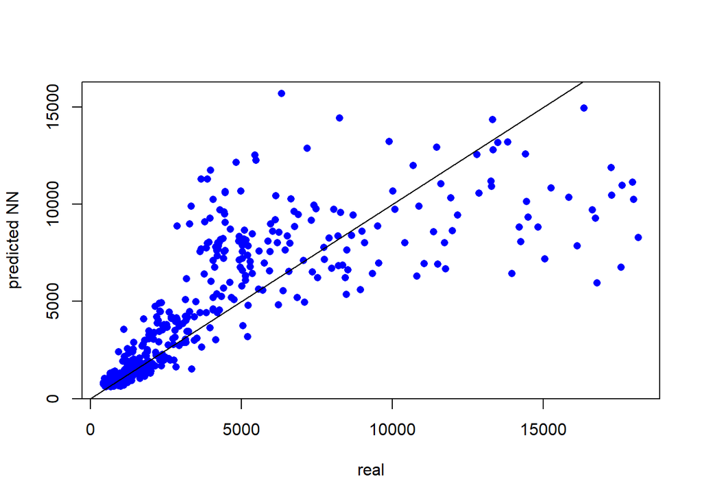

```r
plot(datatest$price, predict_testNN, col='blue', pch=16, ylab = "predicted NN", xlab = "real")
abline(0,1)
```

```r
RMSE.NN = (sum((datatest$price - predict_testNN)^2) / nrow(datatest)) ^ 0.5
RMSE.NN
```

```
## [1] 2435.979904
```

```r
neuralnet(formula, data, hidden = 1, threshold = 0.01, stepmax = 1e+05, rep = 1, startweights = NULL, learningrate.limit = NULL, learningrate.factor = list(minus = 0.5, plus = 1.2), learningrate=NULL, lifesign = "none", lifesign.step = 1000, algorithm = "rprop+", err.fct = "sse", act.fct = "logistic", linear.output = TRUE, exclude = NULL, constant.weights = NULL, likelihood = FALSE)
```

### Параметры neuralnet:

- formula ~ символическое описание модели, подлежащей установке
- data ~ данные, содержащий переменные, указанные в формуле
- hidden ~ вектор целых чисел, определяющий количество скрытых нейронов (вершин) в каждом слое
- threshold ~ числовое значение, определяющее порог для частных производных функции ошибки как критерий остановки.
- stepmax ~ максимальные шаги для обучения нейронной сети. Достижение этого максимума приводит к остановке процесса обучения нейронной сети.
- rep ~ количество повторений для обучения нейронной сети
- startweights ~ вектор, содержащий начальные значения для весов. Весы не будут случайным образом инициализированы
- learningrate.limit ~ вектор или список, содержащий самый низкий и самый высокий предел для скорости обучения. Используется только для RPROP и GRPROP
- learningrate.factor ~ вектор или список, содержащий коэффициенты умножения для верхней и нижней скорости обучения. Используется только для RPROP и GRPROP
- learningrate ~ числовое значение, определяющее скорость обучения, используемую традиционным обратным распространением. Используется только для традиционного backpropagation
- lifesign ~ строка, определяющая, насколько функция будет печататься во время вычисления нейронной сети. ‘none’, ‘minimum’ или ‘full’
- lifesign.stepr ~ целое число, определяющее шаг, чтобы напечатать минимальный порог в режиме полной жизни
- algorithm ~ строка, содержащая тип алгоритма для вычисления нейронной сети. Возможны следующие типы: backprop, rprop +, rprop-, sag или slar. «backprop» относится к backpropagation, «rprop +» и «rprop-» относятся к отказоустойчивой backpropagation с возвратом backtracking и без него, тогда как «sag» и «slr» вызывают использование модифицированного глобально конвергентного алгоритма (grprop).
- err.fct ~ дифференцируемой функции, которая используется для вычисления ошибки. В качестве альтернативы можно использовать строки sse ‘и’ ce ’, которые обозначают сумму квадратов ошибок и кросс-энтропии
- act.fct ~ дифференцируемой функцией, которая используется для сглаживания результата поперечного произведения ковариата или нейронов и весов. Кроме того, для логистической функции и касательной гиперболичности возможны строки, «логистика» и «тань»
- linear.output ~ логичной. Если act.fct не следует применять к выходным нейронам, установите линейный выход в TRUE, иначе FALSE
- exclude ~ вектор или матрицу, определяющую весовые коэффициенты, которые исключаются из расчета. Если задано как вектор, то точное положение весов должно быть известно. Матрица с n-строками и тремя столбцами исключает n весов, где первый столбец обозначает слой, второй столбец для входного нейрона и третий столбец для выходного нейрона веса
- constant.weights ~ вектор, определяющий значения весов, которые исключаются из учебного процесса и рассматриваются как исправление
- likelihood ~ логичной. Если функция ошибки равна отрицательной функции логарифмического правдоподобия, будут вычислены информационные критерии AIC и BIC. Кроме того, использование trust.interval имеет смысл

### Библиотека neuralnet позволяет делать множество внутренних слоёв, а библиотека nnet позволяет делать только один скрытый слой

```r
nnet(x, y, weights, size, Wts, mask, linout = FALSE, entropy = FALSE, softmax = FALSE, censored = FALSE, skip = FALSE, rang = 0.7, decay = 0, maxit = 100, Hess = FALSE, trace = TRUE, MaxNWts = 1000, abstol = 1.0e-4, reltol = 1.0e-8, ...)
```